# SIE-02

## SIC >15

Sea Ice Concentrations need to be greater that 15% to be considered covering, so this code calculates what the percentage is of grid cells within the subset that exceed 15% SIC each year. The data is considered only for only the relevant months (March to October) when female seals are out on their post-moult foraging trip.

```r
# Define the months of interest
months_of_interest <- c(3:10)

# Initialize variables
num_layers <- nlyr(ICE_subset)
coverage_percentages <- numeric(num_layers)

# Calculate coverage for each layer
for (i in 1:num_layers) {
  layer <- ICE_subset[[i]]

  # Create a binary mask indicating whether each grid cell has SIC > 15
  mask <- ifelse(values(layer) > 15, 1, 0)

  # Calculate the percentage of cells with SIC > 15, excluding NAs
  non_zero_count <- sum(mask, na.rm = TRUE)
  total_cells <- sum(!is.na(values(layer)))

  coverage_percentages[i] <- if (total_cells > 0) {
    100 * non_zero_count / total_cells
  } else {
    NA
  }
}

# Create a data frame with coverage percentages and dates
dates <- seq(as.Date("1980-01-01"), by = "months", length.out = num_layers)
df <- data.frame(Date = dates, Coverage = coverage_percentages)

# Filter the data for the months of interest
df$Month <- format(df$Date, "%m")
df$Year <- format(df$Date, "%Y")
df_filtered <- df[df$Month %in% sprintf("%02d", months_of_interest), ]

# Calculate the annual summary (e.g., mean coverage)
annual_summary <- aggregate(Coverage ~ Year, data = df_filtered, FUN = mean, na.rm = TRUE)
```

Quick plot to explore values

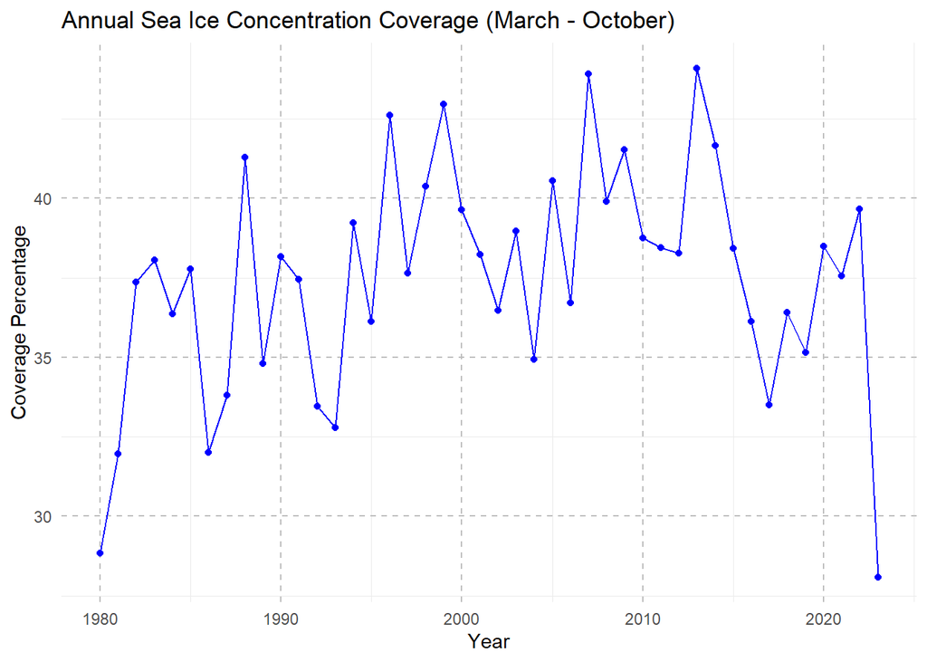

```r
annual_summary$Year <- as.numeric(annual_summary$Year)

# Create a line plot
ggplot(annual_summary, aes(x = Year, y = Coverage)) +
  geom_line(color = "blue") +
  geom_point(color = "blue") +
  labs(title = "Annual Sea Ice Concentration Coverage (March - October)",
       x = "Year",
       y = "Coverage Percentage") +
  theme_minimal() +
  theme(panel.grid.major = element_line(color = "grey", linetype = "dashed"))
```

## Anomaly

Convert percentages to an anomaly value by subtracting each from the total mean of the whole timeseries:

```r
annual_summary$Anomaly <- annual_summary$Coverage - (sum(annual_summary$Coverage)/nrow(annual_summary) )
```

Plot anomalies

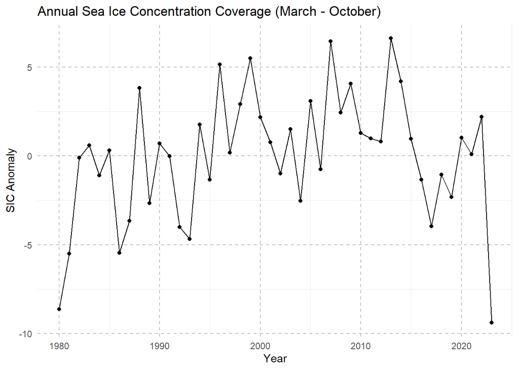

```r
# Create a line plot
ggplot(annual_summary, aes(x = Year, y = Anomaly)) +
  geom_line(color = "black") +
  geom_point(color = "black") +
  labs(title = "Annual Sea Ice Concentration Coverage (March - October)",
       x = "Year",
       y = "SIC Anomaly") +
  theme_minimal() +
  theme(panel.grid.major = element_line(color = "grey", linetype = "dashed"))
```

Make publication Figure:

```r
add_y_break <- function(plot, yval) {
  p2 <- ggplot_build(plot)
  breaks <- p2$layout$panel_params[[1]]$y$breaks
  breaks <- breaks[!is.na(breaks)]
  plot +
    geom_hline(yintercept = yval, color = "grey") +
    scale_y_continuous(breaks = sort(c(yval, breaks)))
}
```

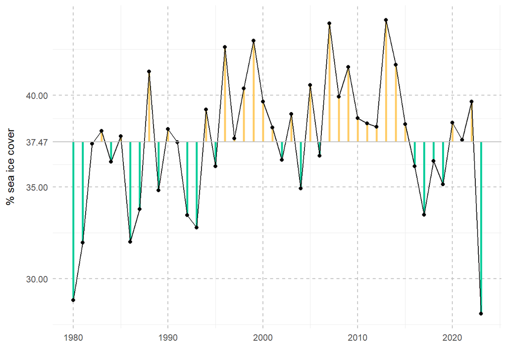

```r
# Base plot
p <- ggplot(annual_summary, aes(x = Year, y = Coverage)) +
  geom_segment(aes(x = Year, xend = Year, y = Coverage, yend = 37.47, color = Anomaly > 0), size = 1) +
  scale_color_manual(values = c("TRUE" = "#FFCC66", "FALSE" = "#00CC99")) +
  geom_line(color = "black") +
  geom_point(color = "black") +
  geom_hline(yintercept = 37.47, color = "grey") +
  # Add label on the right side of the horizontal line
  labs(x = "",
       y = "% sea ice cover") +
  guides(color = "none") +
  theme_minimal() +
  theme(panel.grid.major = element_line(color = "grey", linetype = "dashed"),
        axis.title.y = element_text(margin = margin(r = 10, t=10)))  # Adjust the margin as needed
# Add labeled horizontal line at the average
p <- add_y_break(p, 37.47)

# Print the final plot
print(p)
```

```r
#ggsave("SICplot26.png", plot = p, bg = "transparent", width = 6, height = 2)
```

```r
#write_csv(annual_summary, "annual_SIC.csv")
```